# An Analysis of Congestion in Metro Manila

[Google colab link](https://drive.google.com/file/d/1J-Yn_x-aKEDDFcbLR13Usxn7tEnd-vrL/view?usp=sharing)  
Source: [Wikimedia | patrickroque001](https://commons.wikimedia.org/wiki/File:EDSA_-_Q-Mart,_southbound_traffic_%28Cubao,_Quezon_City;_08-30-2019%29.jpg)

# Abstract

Metro Manila, the capital city of the Philippines, having a high population density of 20,780 per square km, and saturated with establishments and opportunities, has its drawbacks manifested in the daily lives of its residents, such as worsening road traffic, housing shortage, urban poverty, and etc. Exploratory data analysis will be performed on datasets containing data on population, establishments, employment, minimum wage, and urbanization rate per region to find correlationships between the features. The results will be utilized in creating a regression model that will predict the population. Research findings indicate that the congestion in Metro Manila is the result of saturated businesses and job opportunities, as well as higher minimum wage compared with the rest of the country.

# 1. Introduction

## 1.1 Motivation

Manila, the capital city of the Philippines, has once been considered the land of many opportunities. The rapid urbanization and saturation of establishments attracted people around the country to migrate in hopes of greener pastures since the 1970s. This culture of migration still continues today with numerous drawbacks such as congested roads, lack of proper housing, urban poverty, and etc., all affecting the quality of life.

According to [TomTom's 2019 Traffic Index](https://www.tomtom.com/en_gb/traffic-index/ranking/), Metro Manila ranked 2nd in the worst road traffic in the world, placing next to Bangalore, India, both with a congestion index score of 71%. In 2019, the daily traffic for Metro Manila is composed of approximately 3.1 millon vehicles, where commuters lost 257 hours average. This is not the first time that Metro Manila ranked worst in terms of traffic in different studies.

Source: [Wikimedia | Judgefloro](https://commons.wikimedia.org/wiki/File:0584jfBarangays_Maynilad_Water_Services_Marcos_Road_Radial_Road_48_Tondo,_Manilafvf.jpg)

Proper shelter remains a problem for the Philippines, having the third-largest slum population in the region according to East Asia Pacific (EAP) report, titled "Expanding Opportunities for the Urban Poor". Housing and Urban Development Coordinating Council (HUDCC) estimated that 40 percent of informal settlers in the country are in Metro Manila, equivalent to approximately 3 million residents, or 1 of every 4 residents relies in informal housing. This reflects the shortage of affordable housing for the middle and lower class in growing cities. Those deprived of proper housing are left with increased vulnerability against natural disasters, access to infrastructures, physical safety, and tenure insecurity.

The goal of this study is find explore the relevance of the large number of establishments and opportunities in Metro Manila’s population by analyzing datasets from government agencies. Additional questions are expected to come as the research progress.

## 1.2 Research questions

1. How severe is the population congestion in Metro Manila?
2. What factor/s contribute to the congestion?
3. Can the capital be deconcentrated and to what degree?

## 1.3 Research goals

- Gather relevant datasets
- Prepare datasets for analysis
- Visualize and interpret results
- Find factors contributing to congestion in Metro Manila by analzying data
- Propose solutions based on the findings

## 1.4 Methods

Exploratory data analysis (EDA) approach will be used in this project to gather insights from datasets which includes the following steps:

- Checking size of columns, presence of null values, and corresponding data types
- Plotting graphs to better visualize data
- Checking and handling for outliers
- Using correlation heatmap to gauge relationship of features

Once done with the analysis, different regression algorithms will be used to create models that will predict the numerical population value. These models will be assessed based on several performance metrics to choose which will best perform in a simulation.

## 1.5 About

Hi! I'm Nikko Samson and this is my final project in Python for Data Science (UCSanDiegoX - DSE200x) class in edX. As a beginner in data science, I would be happy to hear for your feedback regarding my work so I can continuously improve my knowledge.

Submitted: December 20, 2020

# 2. Loading and Preparing Datasets

## 2.1 Importing libraries

```python
#import libraries
import pandas as pd
import numpy as np
import string
import matplotlib.pyplot as plt
import seaborn as sns
from sklearn.linear_model import LinearRegression, HuberRegressor, RANSACRegressor
from sklearn.model_selection import train_test_split
from sklearn.metrics import mean_squared_error
from sklearn.metrics import accuracy_score
import sklearn.metrics as sm
from math import sqrt
%matplotlib inline
```

## 2.2 Datasets

Total_population_by_geo.csv  
Contents: Philippine population per region for years 2000, 2010 and 2015  
Source: Philippine Statistics Authority (psa.gov.ph)  
https://openstat.psa.gov.ph/PXWeb/pxweb/en/DB/DB__1A__PO/1001A6DTPG0.px/?rxid=3cd004e5-3907-41f9-9983-80ae0d44649a

2015 Population Density_web.xlsx  
Contents: Philippine population density per region for 2015  
Source: Philippine Statistics Authority (psa.gov.ph)  
https://psa.gov.ph/content/philippine-population-density-based-2015-census-population

2010-2018 LE (estab+TE_Ind_Province_MSME).xlsx  
Contents: Number of MSME and employment region in the Philippines from 2010 to 2018  
Source: Department of Trade and Industries (dti.gov.ph)  
https://onedrive.live.com/view.aspx?resid=9CD3CF10466EFD3A!359&ithint=file%2cxlsx&authkey=!ANkdHIzJEh66Teg

Summary_current_regional_daily_minimum_wage_2020.xlsx  
Contents: Minimum wage per region from 1989 to 2020  
Source: National Wages and Productivity Commission DOLE (nwpc.dole.gov.ph)  
https://drive.google.com/drive/u/0/folders/18FU2QYpbeDKhQUrLfdTjqtShkavl9Qox

```python
#mount google drive
from google.colab import drive
drive.mount('/content/drive')
```

```python
#url of datasets
msme_xl_url = '/content/drive/My Drive/Colab Notebooks/Final Project/db/2010-2019 MSME.xlsx'
population_xl_url = '/content/drive/My Drive/Colab Notebooks/Final Project/db/Total_population_by_geo_edited.xlsx'
min_wage_per_region_xl_url = '/content/drive/My Drive/Colab Notebooks/Final Project/db/Summary_current_regional_daily_minimum_wage_2020.xlsx'
```

## 2.3 Cleaning and transformation

The excel file 2010-2019 MSME.xlsx contains data about Micro, Small, and Medium Enterprises in the Philippines. Each sheet contains data for a specific year, from 2010 to 2019. This file is slightly modified to include data from 2019.

*Source: DTI Philippines*

```python
msme_df = pd.read_excel(msme_xl_url, sheet_name='2015LE')
msme_df.head(10)
```

|  | Number of Establishments and Total Employment by Province, Section and Employment Groupings (MSME's3), Philippines: 2015 LE | Unnamed: 1 | Unnamed: 2 | Unnamed: 3 | Unnamed: 4 | Unnamed: 5 | Unnamed: 6 | Unnamed: 7 | Unnamed: 8 | Unnamed: 9 | Unnamed: 10 | Unnamed: 11 | Unnamed: 12 |
| --- | --- | --- | --- | --- | --- | --- | --- | --- | --- | --- | --- | --- | --- |
| 0 | Province \| Section1 | NaN | NaN | Number of Establishments2 | NaN | NaN | NaN | NaN | Total Employment | NaN | NaN | NaN | NaN |
| 1 | NaN | NaN | NaN | Total | Micro | Small | Medium | Large | Total | Micro | Small | Medium | Large |
| 2 | NaN | NaN | NaN | NaN | NaN | NaN | NaN | NaN | NaN | NaN | NaN | NaN | NaN |
| 3 | Philippines | NaN | NaN | 900914 | 806609 | 86367 | 3863 | 4075 | 7766689 | 2285634 | 1968452 | 530784 | 2981819 |
| 4 | National Capital Region (NCR) | NaN | NaN | 191955 | 157677 | 30850 | 1639 | 1789 | 2911554 | 495611 | 752904 | 222950 | 1440089 |
| 5 | NaN | City of Manila | NaN | 35244 | 30679 | 4279 | 138 | 148 | 309591 | 97187 | 94763 | 18724 | 98917 |
| 6 | NaN | NaN | A - Agriculture, Forestry, and Fishing | 18 | 17 | 1 | 0 | 0 | 84 | 65 | 19 | 0 | 0 |
| 7 | NaN | NaN | B - Mining and Quarrying | 5 | 4 | 1 | 0 | 0 | 83 | 11 | 72 | 0 | 0 |
| 8 | NaN | NaN | C - Manufacturing | 2731 | 2388 | 314 | 11 | 18 | 25439 | 8192 | 7756 | 1463 | 8028 |
| 9 | NaN | NaN | D - Electricity, Gas, Steam, and Air Condition... | 7 | 1 | 5 | 0 | 1 | 652 | 3 | 210 | 0 | 439 |

Upon checking the first 10 cells. Some cleaning and formatting work has to done before performing exploration. The header row contains the title, in a merged cell format which translated to null in pandas, while the next one (0) contains the names of the columns.

| Title |  |  |  |  |  |  |  |  |  |  |  |  |
| --- | --- | --- | --- | --- | --- | --- | --- | --- | --- | --- | --- | --- |
|  | Region |  | Establishments |  |  |  |  | Employment |  |  |  |  |
| Region | Subregion | Industry | Total | Micro | Small | Medium | Large | Total | Micro | Small | Medium | Large |

The target columns for extraction from this table are regions, number of establishments, and number of employment. The goal is to extract these values into two tables containing (1) establishments by region and (2) employment by reguion, from 2010 to 2019.

| Establishments by Region |  |  |  |  |
| --- | --- | --- | --- | --- |
| Region | 2010 | 2011 | 2012 | ... |
| Metro Manila | 10005 | 12000 | 13500 | 14800 |

| Employment by Region |  |  |  |  |
| --- | --- | --- | --- | --- |
| Region | 2010 | 2011 | 2012 | ... |
| Metro Manila | 10005 | 12000 | 13500 | 14800 |

Before extracting data, a list of desired regions from the first column of the MSME dataframe will be created and to be used as a filter. Two new dataframes will be declared after, ph_establishments_by_region and ph_employment_by_region, containing the list of regions as the first column

```python
#create list of desired regions to be used as filter.
regions = ['National Capital Region (NCR)', 'Cordillera Administrative Region (CAR)',
           'Ilocos Region', 'Cagayan Valley', 'Central Luzon', 'CALABARZON', 'MIMAROPA', 'Bicol Region',
           'Western Visayas', 'Central Visayas', 'Eastern Visayas', 'Zamboanga Peninsula', 'Northern Mindanao',
           'Davao Region', 'SOCCSKSARGEN', 'Caraga', 'Autonomous Region in Muslim Mindanao (ARMM)']

#declare dataframes containing regions only.
ph_establishments_by_region = pd.DataFrame(regions, columns=['Region'])
ph_employment_by_region = pd.DataFrame(regions, columns=['Region'])
```

Same process goes for the ph_establishments_by_region dataframe.

```python
#using while loop to iterate over 9 sheets
year = 2010
yearend = 2019
while(year != yearend+1):
    #import database
    sheet_name = str(year)+'LE'
    cols = 'A,C,H'
    if(year>2011):
        cols = 'A,D,I'

    df = pd.read_excel(msme_xl_url, sheet_name=sheet_name, usecols=cols)

    region_df = df.loc[df.iloc[:, 0].isin(regions)]
    region_df.columns = ['Region', 'Establishments', 'Employment']
    region_df.reset_index(drop=True, inplace=True)

    ph_establishments_by_region[year] = region_df.Establishments.values
    ph_employment_by_region[year] = region_df.Employment.values

    year+=1
```

```python
#display first five rows of the new dataframes
ph_employment_by_region.head()
```

|  | Region | 2010 | 2011 | 2012 | 2013 | 2014 | 2015 | 2016 | 2017 | 2018 | 2019 |
| --- | --- | --- | --- | --- | --- | --- | --- | --- | --- | --- | --- |
| 0 | National Capital Region (NCR) | 2420767 | 2743094 | 2918489 | 2839371 | 2953102 | 2911554 | 2810870 | 2949627 | 3117670 | 3094419 |
| 1 | Cordillera Administrative Region (CAR) | 68162 | 73678 | 104504 | 97141 | 102469 | 104833 | 106788 | 107204 | 121471 | 123689 |
| 2 | Ilocos Region | 144557 | 157711 | 210705 | 204114 | 208296 | 211106 | 213166 | 214852 | 264496 | 255493 |
| 3 | Cagayan Valley | 76052 | 79908 | 118060 | 119398 | 122648 | 123278 | 123498 | 125987 | 149921 | 148505 |
| 4 | Central Luzon | 430022 | 463297 | 629301 | 646269 | 686165 | 690797 | 704599 | 700104 | 872487 | 844881 |

```python
ph_establishments_by_region.head()
```

|  | Region | 2010 | 2011 | 2012 | 2013 | 2014 | 2015 | 2016 | 2017 | 2018 | 2019 |
| --- | --- | --- | --- | --- | --- | --- | --- | --- | --- | --- | --- |
| 0 | National Capital Region (NCR) | 210574 | 213594 | 212351 | 209765 | 211854 | 191955 | 187650 | 194134 | 205250 | 204005 |
| 1 | Cordillera Administrative Region (CAR) | 14079 | 15311 | 18243 | 18198 | 18267 | 18119 | 18992 | 19203 | 20466 | 20453 |
| 2 | Ilocos Region | 42202 | 43495 | 48751 | 48713 | 48955 | 48042 | 48649 | 48719 | 50877 | 50848 |
| 3 | Cagayan Valley | 23723 | 24281 | 28406 | 28406 | 28581 | 27823 | 29038 | 29215 | 30753 | 30724 |
| 4 | Central Luzon | 79219 | 83476 | 105576 | 105389 | 105754 | 101176 | 103546 | 103634 | 116458 | 116255 |

Since the columns in the source contains a mix of strings and numeric values, it is also important to check the datatypes.

```python
ph_establishments_by_region.dtypes
```

```
Region    object
2010      object
2011      object
2012      object
2013      object
2014      object
2015      object
2016      object
2017      object
2018      object
2019      object
dtype: object
```

```python
#function to convert columns to numeric type
def cols_to_int(df):
  cols = [i for i in df.columns if i not in ["Region"]]
  for col in cols:
      df[col]=pd.to_numeric(df[col])
```

```python
cols_to_int(ph_establishments_by_region)
cols_to_int(ph_employment_by_region)
ph_establishments_by_region.dtypes
```

```
Region    object
2010       int64
2011       int64
2012       int64
2013       int64
2014       int64
2015       int64
2016       int64
2017       int64
2018       int64
2019       int64
dtype: object
```

```python
#function to display i
def my_df_info(df, table_name):
  print(table_name)
  print('------------------------------')
  print('Are there null values? : ', df.isnull().values.any())
  print('Dataframe size         : ', df.shape)
  print('')
```

```python
my_df_info(ph_establishments_by_region, 'PH establishments by region df')
my_df_info(ph_employment_by_region, 'PH employment by region df')
```

```
PH establishments by region df
------------------------------
Are there null values? :  False
Dataframe size         :  (17, 11)

PH employment by region df
------------------------------
Are there null values? :  False
Dataframe size         :  (17, 11)
```

The population dataset looks okay as is and doesn't require cleaning. It contains the land area of the region and its population for years 2000, 2010, and 2015.

```python
population_df = pd.read_excel(population_xl_url, sheet_name='2000-2015')
population_df = population_df[1:].reset_index(drop=True)
#converting years name to int for uniformity with previous
population_df.rename(columns={'2000':2000, '2010':2010, '2015':2015}, inplace=True)
population_df.head()
```

|  | Region | LandArea(kmsq) | 2000 | 2010 | 2015 |
| --- | --- | --- | --- | --- | --- |
| 0 | National Capital Region (NCR) | 619.54 | 9932560 | 11855975 | 12877253 |
| 1 | Cordillera Administrative Region (CAR) | 19818.12 | 1365412 | 1616867 | 1722006 |
| 2 | Ilocos Region | 12964.62 | 4200478 | 4748372 | 5026128 |
| 3 | Cagayan Valley | 29836.88 | 2813159 | 3229163 | 3451410 |
| 4 | Central Luzon | 21906.19 | 8204742 | 10137737 | 11218177 |

The next line of codes will create a new dataframe of population density per region by dividing the population column with the land area.

```python
density_df = population_df.copy()
density_df[[2000, 2010, 2015]] = density_df[[2000, 2010, 2015]].div(density_df['LandArea(kmsq)'], axis=0)
density_df.head()
```

|  | Region | LandArea(kmsq) | 2000 | 2010 | 2015 |
| --- | --- | --- | --- | --- | --- |
| 0 | National Capital Region (NCR) | 619.54 | 16032.152888 | 19136.738548 | 20785.184169 |
| 1 | Cordillera Administrative Region (CAR) | 19818.12 | 68.897151 | 81.585287 | 86.890482 |
| 2 | Ilocos Region | 12964.62 | 323.995458 | 366.256165 | 387.680318 |
| 3 | Cagayan Valley | 29836.88 | 94.284624 | 108.227234 | 115.675969 |
| 4 | Central Luzon | 21906.19 | 374.539890 | 462.779561 | 512.100781 |

```python
population_df.dtypes
```

```
Region             object
LandArea(kmsq)    float64
2000                int64
2010                int64
2015                int64
dtype: object
```

```python
my_df_info(population_df, 'Population dataframe')
my_df_info(density_df, 'Density dataframe')
```

```
Population dataframe
------------------------------
Are there null values? :  False
Dataframe size         :  (17, 5)

Density dataframe
------------------------------
Are there null values? :  False
Dataframe size         :  (17, 5)
```

A dataset containing the urbanization level of each region.

```python
urbanization_df = pd.read_excel(population_xl_url, sheet_name='Urbanization')
urbanization_df = urbanization_df[1:].reset_index(drop=True)
#converting years name to int for uniformity with previous
urbanization_df.rename(columns={'2000':2000, '2010':2010, '2015':2015}, inplace=True)
urbanization_df.head()
```

|  | Region | 2010 | 2015 |
| --- | --- | --- | --- |
| 0 | National Capital Region (NCR) | 100.0 | 100.0 |
| 1 | Cordillera Administrative Region (CAR) | 26.3 | 30.5 |
| 2 | Ilocos Region | 12.7 | 20.5 |
| 3 | Cagayan Valley | 11.6 | 19.2 |
| 4 | Central Luzon | 51.6 | 61.6 |

Lastly, an excel file containing the minimum wage (non-agriculture) per region.

```python
min_wage_df = pd.read_excel(min_wage_per_region_xl_url)
min_wage_df.head()
```

|  | Region | 1989 | 1990 | 1991 | 1992 | 1993 | 1994 | 1995 | 1996 | 1997 | 1998 | 1999 | 2000 | 2001 | 2002 | 2003 | 2004 | 2005 | 2006 | 2007 | 2008 | 2009 | 2010 | 2011 | 2012 | 2013 | 2014 | 2015 | 2016 | … |
| --- | --- | --- | --- | --- | --- | --- | --- | --- | --- | --- | --- | --- | --- | --- | --- | --- | --- | --- | --- | --- | --- | --- | --- | --- | --- | --- | --- | --- | --- | --- |
| 0 | National Capital Region (NCR) | 89 | 106 | 118.0 | 118.0 | 135.0 | 145.0 | 145.0 | 165.0 | 185.0 | 198.0 | 223.5 | 250.0 | 265.0 | 280.0 | 280.0 | 300.0 | 325.0 | 350.0 | 362.0 | 382 | 382 | 404 | 426 | 446.0 | 466.0 | 466.0 | 481.0 | 491.0 | … |
| 1 | Cordillera Administrative Region (CAR) | 89 | 89 | 89.0 | 89.0 | 89.0 | 119.0 | 119.0 | 129.0 | 147.0 | 155.0 | 170.0 | 178.0 | 185.0 | 190.0 | 190.0 | 205.0 | 225.0 | 235.0 | 235.0 | 260 | 260 | 260 | 272 | 280.0 | 280.0 | 280.0 | 285.0 | 285.0 | … |
| 2 | Ilocos Region | 89 | 101 | 109.0 | 109.0 | 124.0 | 124.0 | 124.0 | 132.0 | 148.0 | 166.0 | 183.0 | 190.0 | 190.0 | 190.0 | 190.0 | 200.0 | 212.0 | 225.0 | 230.0 | 240 | 240 | 240 | 248 | 253.0 | 253.0 | 253.0 | 253.0 | 280.0 | … |
| 3 | Cagayan Valley | 89 | 101 | 101.0 | 101.0 | 116.0 | 116.0 | 116.0 | 131.0 | 145.0 | 160.0 | 172.0 | 180.0 | 180.0 | 185.0 | 185.0 | 193.0 | 208.0 | 218.0 | 223.0 | 235 | 235 | 235 | 245 | 255.0 | 255.0 | 255.0 | 255.0 | 300.0 | … |
| 4 | Central Luzon | 89 | 103 | 112.0 | 112.0 | 112.0 | 127.0 | 127.0 | 147.0 | 163.5 | 175.5 | 175.5 | 208.5 | 208.5 | 228.5 | 228.5 | 243.5 | 263.5 | 287.0 | 287.0 | 302 | 302 | 316 | 330 | 336.0 | 336.0 | 349.0 | 349.0 | 364.0 | … |

```python
min_wage_df.dtypes
```

```
Region     object
1989        int64
1990        int64
1991      float64
1992      float64
1993      float64
1994      float64
1995      float64
1996      float64
1997      float64
1998      float64
1999      float64
2000      float64
2001      float64
2002      float64
```

[output cut: 19 more lines]

```python
my_df_info(min_wage_df, 'Minimum wage (non-agriculture) per region')
```

```
Minimum wage (non-agriculture) per region
------------------------------
Are there null values? :  False
Dataframe size         :  (17, 33)
```

## 2.4 Limitations

- The project’s focus is on Metro Manila. It would also be interesting to have a deeper look at other regions, analyzing different sectors, and geographic factors.
- The samples available for machine learning is limited to 34 - of which 90% will be used in training - due to limited data.

# 3. Exploratory Analysis and Visualization

## 3.1 Overview

```python
#function to create summarized dataframe of year
def summarized_df(year):
  df = ph_establishments_by_region[['Region', year]].copy()
  df.rename(columns={year:'Establishments'}, inplace=True)
  df['Employment'] = ph_employment_by_region[year].copy()
  df['Population'] = population_df[year].copy()
  df['PopDensity'] = density_df[year].copy()
  df['MinWage'] = min_wage_df[year].copy()
  df['UrbanizationLvl'] = urbanization_df[year].copy()
  return df
```

```python
#create summary of 2015 and sort by population
ph_2015_df = summarized_df(2015)
```

```python
ph_2015_df
```

|  | Region | Establishments | Employment | Population | PopDensity | MinWage | UrbanizationLvl |
| --- | --- | --- | --- | --- | --- | --- | --- |
| 0 | National Capital Region (NCR) | 191955 | 2911554 | 12877253 | 20785.184169 | 481.0 | 100.0 |
| 1 | Cordillera Administrative Region (CAR) | 18119 | 104833 | 1722006 | 86.890482 | 285.0 | 30.5 |
| 2 | Ilocos Region | 48042 | 211106 | 5026128 | 387.680318 | 253.0 | 20.5 |
| 3 | Cagayan Valley | 27823 | 123278 | 3451410 | 115.675969 | 255.0 | 19.2 |
| 4 | Central Luzon | 101176 | 690797 | 11218177 | 512.100781 | 349.0 | 61.6 |
| 5 | CALABARZON | 131700 | 1229820 | 14414774 | 869.603517 | 362.5 | 66.4 |
| 6 | MIMAROPA | 26673 | 102585 | 2963360 | 100.092379 | 285.0 | 30.6 |
| 7 | Bicol Region | 34136 | 169162 | 5796989 | 320.019796 | 265.0 | 23.2 |
| 8 | Western Visayas | 34906 | 192635 | 4477247 | 350.511686 | 298.5 | 38.1 |
| 9 | Central Visayas | 53608 | 610451 | 6041903 | 578.061349 | 353.0 | 49.4 |
| 10 | Eastern Visayas | 27199 | 128126 | 4440150 | 191.099292 | 260.0 | 11.9 |
| 11 | Zamboanga Peninsula | 31137 | 142742 | 3629783 | 214.728855 | 280.0 | 37.8 |
| 12 | Northern Mindanao | 35977 | 240952 | 4689302 | 229.210338 | 318.0 | 48.5 |
| 13 | Davao Region | 46888 | 335941 | 4893318 | 239.476680 | 317.0 | 63.5 |
| 14 | SOCCSKSARGEN | 36637 | 218475 | 4545276 | 199.475996 | 275.0 | 51.6 |
| 15 | Caraga | 16693 | 98055 | 2596709 | 122.946977 | 268.0 | 33.5 |
| 16 | Autonomous Region in Muslim Mindanao (ARMM) | 9305 | 38520 | 3781387 | 103.172960 | 250.0 | 23.2 |

```python
ph_2015_df.describe()
```

|  | Establishments | Employment | Population | PopDensity | MinWage | UrbanizationLvl |
| --- | --- | --- | --- | --- | --- | --- |
| count | 17.000000 | 1.700000e+01 | 1.700000e+01 | 17.000000 | 17.000000 | 17.000000 |
| mean | 51292.588235 | 4.440607e+05 | 5.680304e+06 | 1494.466561 | 303.235294 | 41.735294 |
| std | 47428.526050 | 7.027074e+05 | 3.627494e+06 | 4975.394205 | 58.294810 | 22.299158 |
| min | 9305.000000 | 3.852000e+04 | 1.722006e+06 | 86.890482 | 250.000000 | 11.900000 |
| 25% | 27199.000000 | 1.232780e+05 | 3.629783e+06 | 122.946977 | 265.000000 | 23.200000 |
| 50% | 34906.000000 | 1.926350e+05 | 4.545276e+06 | 229.210338 | 285.000000 | 37.800000 |
| 75% | 48042.000000 | 3.359410e+05 | 5.796989e+06 | 387.680318 | 318.000000 | 51.600000 |
| max | 191955.000000 | 2.911554e+06 | 1.441477e+07 | 20785.184169 | 481.000000 | 100.000000 |

- The maximum values of establishments, employment, and population is notably higher than the minimum and 75% percentile.
- Values from urbanization level suggests that 25% of samples in the dataset has an urbanization value greater than 51.5% and tend to have higher values in different features as in the previous observation.
- The maximum value of population density is remarkably higher than the minimum and 75% percentile.
- Third observation suggests presence of extreme outlier(s) in the dataset.

## 3.2 Distribution

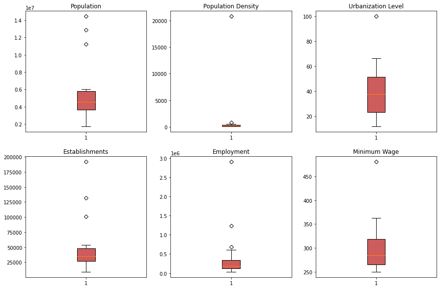

```python
fig, axs = plt.subplots(2, 3, figsize=(15,10))
axs[0, 0].boxplot(ph_2015_df['Population'], sym='D', patch_artist=True, boxprops=dict(facecolor='indianred'))
axs[0, 0].set_title('Population')
axs[0, 1].boxplot(ph_2015_df['PopDensity'], sym='D', patch_artist=True, boxprops=dict(facecolor='indianred'))
axs[0, 1].set_title('Population Density')
axs[0, 2].boxplot(ph_2015_df['UrbanizationLvl'], sym='D', patch_artist=True, boxprops=dict(facecolor='indianred'))
axs[0, 2].set_title('Urbanization Level')
axs[1, 0].boxplot(ph_2015_df['Establishments'], sym='D', patch_artist=True, boxprops=dict(facecolor='indianred'))
axs[1, 0].set_title('Establishments')
axs[1, 1].boxplot(ph_2015_df['Employment'], sym='D', patch_artist=True, boxprops=dict(facecolor='indianred'))
axs[1, 1].set_title('Employment')
axs[1, 2].boxplot(ph_2015_df['MinWage'], sym='D', patch_artist=True, boxprops=dict(facecolor='indianred'))
axs[1, 2].set_title('Minimum Wage')
plt.show()
```

- Three outliers are detected in population, establishments, and employment.
- Two outliers are detected in population density, with one being extreme, harshly affecting the distribution range.
- One outlier detected in minimum wage and urbanization level.

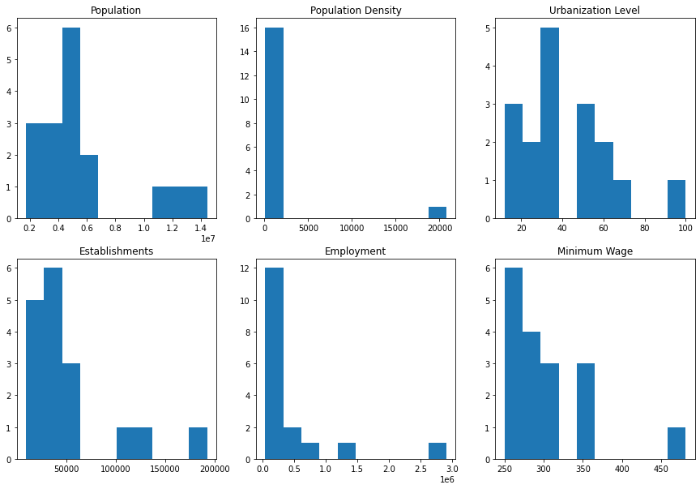

```python
fig, axs = plt.subplots(2, 3, figsize=(15,10))
axs[0, 0].hist(ph_2015_df['Population'])
axs[0, 0].set_title('Population')
axs[0, 1].hist(ph_2015_df['PopDensity'])
axs[0, 1].set_title('Population Density')
axs[0, 2].hist(ph_2015_df['UrbanizationLvl'])
axs[0, 2].set_title('Urbanization Level')
axs[1, 0].hist(ph_2015_df['Establishments'])
axs[1, 0].set_title('Establishments')
axs[1, 1].hist(ph_2015_df['Employment'])
axs[1, 1].set_title('Employment')
axs[1, 2].hist(ph_2015_df['MinWage'])
axs[1, 2].set_title('Minimum Wage')
plt.show()
```

- Shape: distribution is skewed right where distribution is higher on the lower values.
- Gaps in the histogram shows that the variables are discrete and outliers are present.
- Large gap in population density indicates an extreme outlier.

## 3.3 Population and density

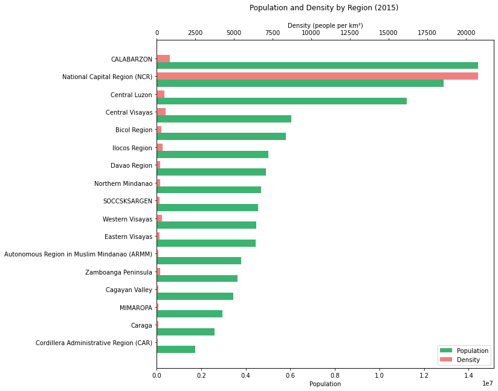

```python
ph_2015_df_sorted = ph_2015_df.sort_values(by='Population', ascending=True)
population = ph_2015_df_sorted['Population']
density = ph_2015_df_sorted['PopDensity']
region = ph_2015_df_sorted['Region']
minwage = ph_2015_df_sorted['MinWage']
urbanization = ph_2015_df_sorted['UrbanizationLvl']

z = np.arange(len(region))
width = 0.4

fig, ax = plt.subplots(figsize=(10,10))
#bar1
ax.barh(z-width/2, population, width, color='mediumseagreen', label='Population', tick_label=region)
ax.set_xlabel("Population")
#bar2
ax2 = ax.twiny()
ax2.barh(z+width/2, density, width, color='lightcoral', label='Density', tick_label=region)
ax2.set_xlabel("Density (people per km²)")
#legends
fig.legend(loc="lower right", bbox_to_anchor=(1,0), bbox_transform=ax.transAxes)

plt.title("Population and Density by Region (2015) \n")
plt.show()
```

## 3.4 Establishments and employment

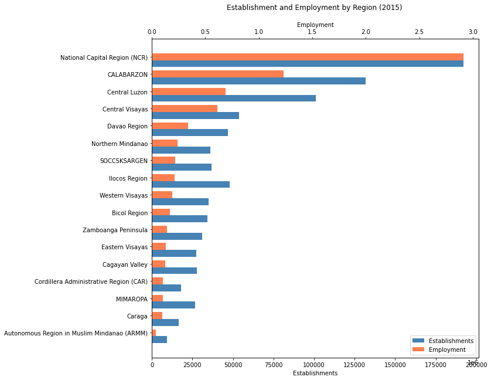

```python
ph_2015_df_sorted = ph_2015_df.sort_values(by='Employment', ascending=True)
region = ph_2015_df_sorted['Region']
minwage = ph_2015_df_sorted['MinWage']
employment = ph_2015_df_sorted['Employment']
establishments = ph_2015_df_sorted['Establishments']
urbanization = ph_2015_df_sorted['UrbanizationLvl']

z = np.arange(len(region))
width = 0.4

fig, ax = plt.subplots(figsize=(10,10))
#bar1
ax.barh(z-width/2, establishments, width, color='steelblue', label='Establishments', tick_label=region)
ax.set_xlabel("Establishments")
#bar2
ax2 = ax.twiny()
ax2.barh(z+width/2, employment, width, color='coral', label='Employment', tick_label=region)
ax2.set_xlabel("Employment")
#legends
fig.legend(loc="lower right", bbox_to_anchor=(1,0), bbox_transform=ax.transAxes)

plt.title("Establishment and Employment by Region (2015) \n")
plt.show()
```

The number of establishments and jobs in Metro Manila is remarkably higher compared to the other regions, which is followed by its neighbors, CALABARZON and Central Luzon, then Central Visayas, a highly urbanized region in the middle island group of the country.

Data shows that not only the population is dense in the capital but also the establishments.

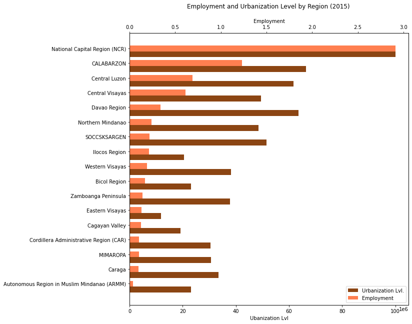

```python
z = np.arange(len(region))
width = 0.4

fig, ax = plt.subplots(figsize=(10,10))
#bar1
ax.barh(z-width/2, urbanization, width, color='saddlebrown', label='Urbanization Lvl.', tick_label=region)
ax.set_xlabel("Ubanization Lvl")
#bar2
ax2 = ax.twiny()
ax2.barh(z+width/2, employment, width, color='coral', label='Employment', tick_label=region)
ax2.set_xlabel("Employment")
#legends
fig.legend(loc="lower right", bbox_to_anchor=(1,0), bbox_transform=ax.transAxes)

plt.title("Employment and Urbanization Level by Region (2015) \n")
plt.show()
```

[figure not shown]

```python
ph_2015_df_sorted = ph_2015_df.sort_values(by='MinWage', ascending=True)
minwage = ph_2015_df_sorted['MinWage']

z = np.arange(len(region))
width = 0.5

fig, ax = plt.subplots(figsize=(10,10))
#bar1
ax.barh(z, minwage, width, color='slategrey', tick_label=region)
ax.set_xlabel("Minimum wage (PHP)")

plt.title("Minimum Wage (non-agriculture) per Region (2015) \n")
plt.show()
```

## 3.5 Correlation heatmap

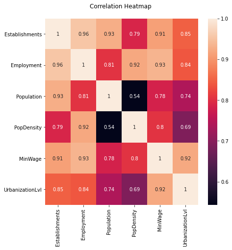

```python
fig, ax = plt.subplots(figsize=(7,7))
ax = sns.heatmap(ph_2015_df.corr(), annot=True)
plt.title("Correlation Heatmap \n")
plt.show()
```

The heatmap shows that the number of establishments and employment, urbanization level and minimum wage have strong correlation with the population in a region. These features will be used creating a regression model to predict the population.

[figure not shown]

```python
fig, (ax1, ax2, ax3, ax4) = plt.subplots(1, 4, figsize=(20,5))
ax1.scatter(establishments, population, color='g')
ax1.set_title("Scatter Plot of Population and Establishments\nCorr = .93")
ax1.set(xlabel="Establishments", ylabel="Population")
ax2.scatter(establishments, employment, color='b')
ax2.set_title("Scatter Plot of Population and Employment\nCorr = .81")
ax2.set(xlabel="Employment", ylabel="Population")
ax3.scatter(urbanization, population, color='r')
ax3.set_title("Scatter Plot of Population and Urbanization Level\nCorr = .74")
ax3.set(xlabel="Urbanization Lvl.", ylabel="Population")
ax4.scatter(minwage, population, color='y')
ax4.set_title("Scatter Plot of Population and Minimum Wage\nCorr = .78")
ax4.set(xlabel="Min. Wage", ylabel="Population")
plt.show()
```

# 4. Modeling

## 4.1 Preparing datasets for training

```python
#add year column
ph_2015_df['Year'] = 2015

#create df for 2010
ph_2010_df = summarized_df(2010)
ph_2010_df['Year'] = 2010

#create new dataframe with apppended values
merged_ph_df = ph_2015_df.append(ph_2010_df).copy()
merged_ph_df.reset_index(drop=True, inplace=True)

#store test results and accuracy scores of each regression algorithm
score_df = pd.DataFrame(columns = ['Algorithm', 'Mean Abs Error', 'Mean ^2 Error', 'R^2 Score'])
```

```python
#function to store scores and test results
def store_score(algo, score_df, y_prediction):
  score_df = score_df.append({
    'Algorithm': algo,
    'Mean Abs Error' : round(sm.mean_absolute_error(y_test, y_prediction), 2),
    'Mean ^2 Error' : round(sm.mean_squared_error(y_test, y_prediction), 2),
    'R^2 Score': round(sm.r2_score(y_test, y_prediction), 2)},
    ignore_index=True)
  results[algo] = y_prediction
  return score_df
```

```python
merged_ph_df.head()
```

|  | Region | Establishments | Employment | Population | PopDensity | MinWage | UrbanizationLvl | Year |
| --- | --- | --- | --- | --- | --- | --- | --- | --- |
| 0 | National Capital Region (NCR) | 191955 | 2911554 | 12877253 | 20785.184169 | 481.0 | 100.0 | 2015 |
| 1 | Cordillera Administrative Region (CAR) | 18119 | 104833 | 1722006 | 86.890482 | 285.0 | 30.5 | 2015 |
| 2 | Ilocos Region | 48042 | 211106 | 5026128 | 387.680318 | 253.0 | 20.5 | 2015 |
| 3 | Cagayan Valley | 27823 | 123278 | 3451410 | 115.675969 | 255.0 | 19.2 | 2015 |
| 4 | Central Luzon | 101176 | 690797 | 11218177 | 512.100781 | 349.0 | 61.6 | 2015 |

```python
#define features and target
features = ['Establishments', 'Employment', 'MinWage', 'UrbanizationLvl']
target = ['Population']

#extract features and target values into separate dataframes
X = merged_ph_df[features]
y = merged_ph_df[target]
```

```python
#split dataset into training and testing
X_train, X_test, y_train, y_test = train_test_split(X, y, test_size=0.1, random_state=47)

#df to store results
results = y_test.copy()
results.rename(columns={'Population': 'Target'}, inplace='True')
```

## 4.2 Linear regression

```python
#fit model to training set
linear = LinearRegression().fit(X_train, y_train)
```

```python
score_df = store_score('Linear', score_df, linear.predict(X_test))
```

## 4.3 Huber regression

```python
huber = HuberRegressor().fit(X_train, y_train.values.ravel())
```

```python
score_df = store_score('Huber', score_df, huber.predict(X_test))
```

## 4.4 Ransac regression

```python
ransac = RANSACRegressor().fit(X_train, y_train)
```

```python
score_df = store_score('RANSAC', score_df, ransac.predict(X_test))
```

## 4.5 Model evaluation

```python
score_df
```

|  | Algorithm | Mean Abs Error | Mean ^2 Error | R^2 Score |
| --- | --- | --- | --- | --- |
| 0 | Linear | 469425.46 | 3.110981e+11 | 0.75 |
| 1 | Huber | 373012.16 | 1.603391e+11 | 0.87 |
| 2 | RANSAC | 685149.50 | 8.042768e+11 | 0.36 |

```python
results
```

|  | Target | Linear | Huber | RANSAC |
| --- | --- | --- | --- | --- |
| 32 | 2429224 | 2.168599e+06 | 2.113869e+06 | 2.780768e+06 |
| 28 | 3407353 | 3.495613e+06 | 3.574202e+06 | 3.161961e+06 |
| 26 | 5513514 | 4.753410e+06 | 4.962898e+06 | 7.191836e+06 |
| 3 | 3451410 | 4.220122e+06 | 3.910640e+06 | 3.916751e+06 |

Based on the test results and performance measurements, Huber regressor performed best among the three.

# 5. Deploying the Model

In this section, the model created from the previous chapter will be used to simulate the population in Metro Manila by adjusting the factor values.

## 5.1 Simulation

```python
merged_ph_df.head()
```

|  | Region | Establishments | Employment | Population | PopDensity | MinWage | UrbanizationLvl | Year |
| --- | --- | --- | --- | --- | --- | --- | --- | --- |
| 0 | National Capital Region (NCR) | 191955 | 2911554 | 12877253 | 20785.184169 | 481.0 | 100.0 | 2015 |
| 1 | Cordillera Administrative Region (CAR) | 18119 | 104833 | 1722006 | 86.890482 | 285.0 | 30.5 | 2015 |
| 2 | Ilocos Region | 48042 | 211106 | 5026128 | 387.680318 | 253.0 | 20.5 | 2015 |
| 3 | Cagayan Valley | 27823 | 123278 | 3451410 | 115.675969 | 255.0 | 19.2 | 2015 |
| 4 | Central Luzon | 101176 | 690797 | 11218177 | 512.100781 | 349.0 | 61.6 | 2015 |

What is the population of Metro Manila if X percentage of establishments and jobs were transferred to other regions?

```python
#function to predict and print results
def predict_ncr(factor):
  test_set = {'Establishments': [(191955*factor)],
            'Employment': [(2911554*factor)],
            'MinWage': [481],
            'UrbanizationLvl': [100]}
  test_df = pd.DataFrame(data=test_set)
  y_prediction = huber.predict(test_df)
  print('Metro Manila after moving ', (100-(factor*100)), '%')
  print('of establishments and jobs to other regions')
  print('-------------------------------------------')
  print('Population: ', y_prediction)
  print('Density   : ', (y_prediction/619.54), ' persons per square kilometers')
  print('')
```

```python
predict_ncr(.75)
predict_ncr(.5)
predict_ncr(.25)
```

```
Metro Manila after moving  25.0 %
of establishments and jobs to other regions
-------------------------------------------
Population:  [10043709.98851104]
Density   :  [16211.56017127]  persons per square kilometers

Metro Manila after moving  50.0 %
of establishments and jobs to other regions
-------------------------------------------
Population:  [7210167.78021582]
Density   :  [11637.93747008]  persons per square kilometers

Metro Manila after moving  75.0 %
of establishments and jobs to other regions
-------------------------------------------
Population:  [4376625.5719206]
Density   :  [7064.31476889]  persons per square kilometers
```

# 6. Conclusion

## 6.2 Contributing factors

- High concentration of establishments
- Saturation of establishments translates to more employment opportunities
- Rapid growth of establishments contributed to rate of urbanization resulting to relatively higher minimum wage

## 6.3 Deconcentration

```
Metro Manila Population
    After Moving Percentage of
    Establishments and Employment
    to Other Regions (2015)
```

%

Establishments

Employment

Population

Density

100%

191,955

2,911,554

12,877,253

20,785

75%

143,966

2,183,665

10,043,710

16,212

50%

95,977

1,455,777

7,210,168

11,638

25%

47,989

727,888

4,376,626

7,064

Based on the prediction of the model, Metro Manila will remain dense for its size even after moving as much as 75% of establishments and jobs to other regions. However, the impact would greatly improve the worsening living condition in the mega city in terms of road traffic, cost of housing, urban poverty, slums, labor exploitation, and etc.

For other regions receiving the establishments, the movement would not only generate jobs but also increase its urbanization level, then the minimum wage will soon follow which should attract former city migrants to return to their native origin.

# 7. Acknowledgement

I would like to extend my thanks to my friend Jomar, for sharing his insights on economics and reviewing some parts of my final project.

Also, some threads from stackoverflow.com provided great reference for me in coding for this project.

# 8. References

- Tomtom (2019). *Traffic Index 2019*. Retrieved from https://www.tomtom.com/en_gb/traffic-index/ranking/.
- UNESCO (2018). *Overview of Internal Migration in the Philippines*. Retrieved from https://bangkok.unesco.org/content/policy-briefs-internal-migration-southeast-asia
- Worldbank. *East Asia and Pacific Cities: Expanding Opportunities for the Urban Poor*. Retrieved from https://www.worldbank.org/en/region/eap/publication/east-asia-and-pacific-cities-expanding-opportunities-for-the-urban-poor
- Philippine Statistics Authority. *Population datasets*. Retrieved from https://openstat.psa.gov.ph/Database
- Department of Trade and Industries. *MSME datasets*. Retrieved from https://www.dti.gov.ph/faps/msmes/.
- National Wage and Productivity Commission. Minimum wage datasets. Retrieved from https://nwpc.dole.gov.ph/.